# 3 Distributions

What is distribution? We use this word all the time.

When speaking about distributions, we mean **the law of distribution of a random variable** – the correspondence between the possible values of this variable from the range of its admissible values and: the probabilities of these values – for a discrete variable, or the probability density – for a continuous variable.

## 3.1 5.1 Types of distributions

The laws of probability distributions can not be derived for all quantities! But it so happened that we can describe some patterns, probability distributions, with formulas, as in physics: the force of gravity (the force with which the Earth attracts all bodies) is directly proportional to the mass of the object, taken with the coefficient of acceleration of free fall $F = m*g$.. We noticed this in relation to the surrounding world and derived a law (not we personally, but representatives of the planet Earth in general). The same is with distributions: we noticed that the probabilities of the distribution of some random variables obey certain laws, and wrote them down. For example, it has been proven that continuous random variables, which are affected by many random factors (for example, height, weight, etc.), are distributed in accordance with **the Gaussian distribution** , also known as **the normal distribution** . Its formula is:

$P(x) = \frac{e^{-(x - \mu)^{2}/(2\sigma^{2}) }} {\sigma\sqrt{2\pi}}$

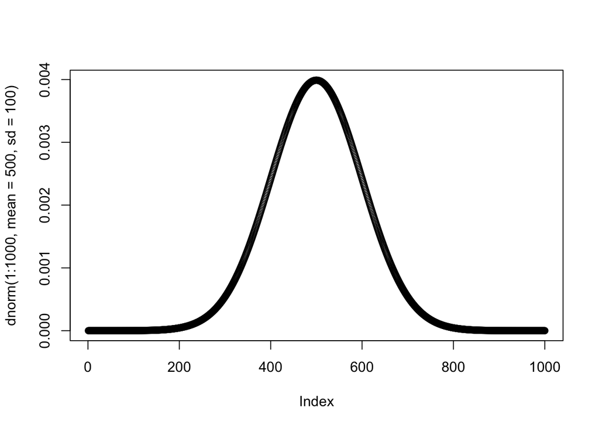

```r
plot(dnorm(1:1000, mean = 500, sd = 100))
```

Or, for example, the exponential distribution:

$P(x)= \lambda \times e^{-\lambda x}$

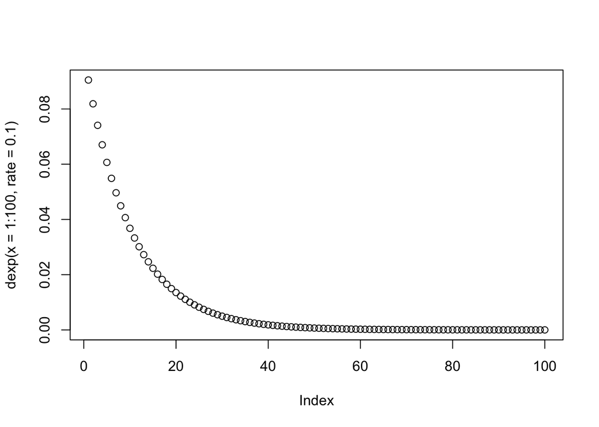

```r
plot(dexp(x = 1:100, rate = 0.1))
```

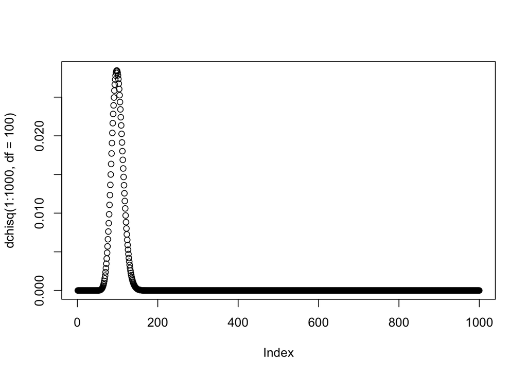

```r
plot(dchisq(1:1000, df=100))
```

Or, for example, the binomial distribution:

$P(k | n, p) = \frac{n!}{k!(n-k)!} \times p^k \times (1-p)^{n-k} = {n \choose k} \times p^k \times (1-p)^{n-k}$

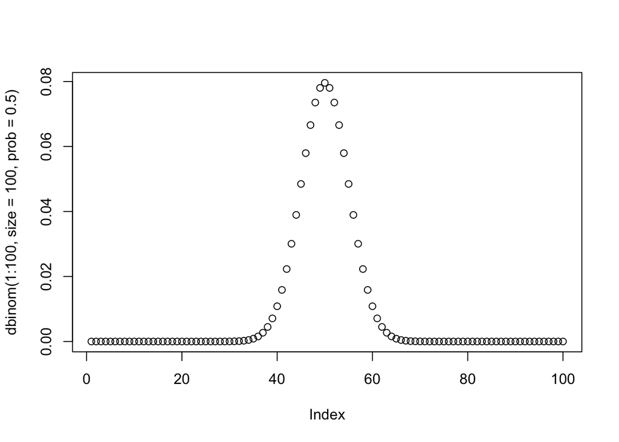

```r
plot(dbinom(1:100, size=100, prob=0.5))
```

You can look and be horrified here http://www.math.wm.edu/~leemis/chart/UDR/UDR.html . Fortunately, we won’t need any of this.

Less scary version https://www.johndcook.com/blog/distribution_chart/#normal

## 3.2 5.2 Distribution functions

Above we got acquainted with probability density, let’s record all the functions applicable to probability that are useful:

Why are they needed?

Let’s look at the example of IQ tests.

**Probability density function**

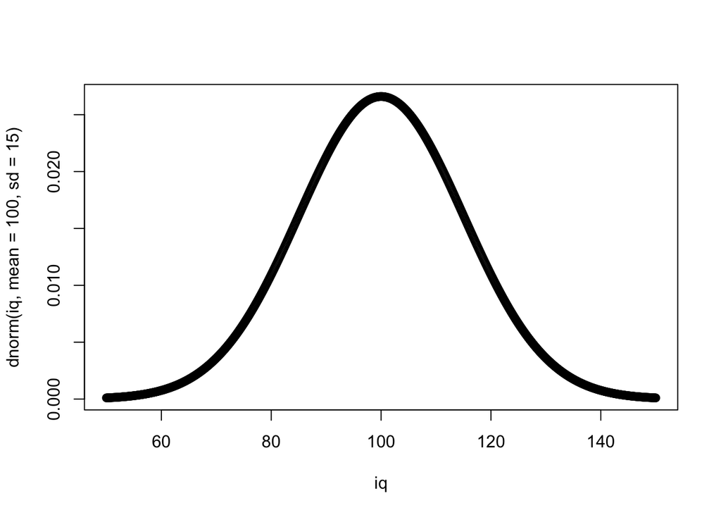

```r
iq <- seq(50,150, 0.1)
plot(iq, dnorm(iq, mean = 100, sd = 15))
```

**Cumulative distribution function (cdf)**

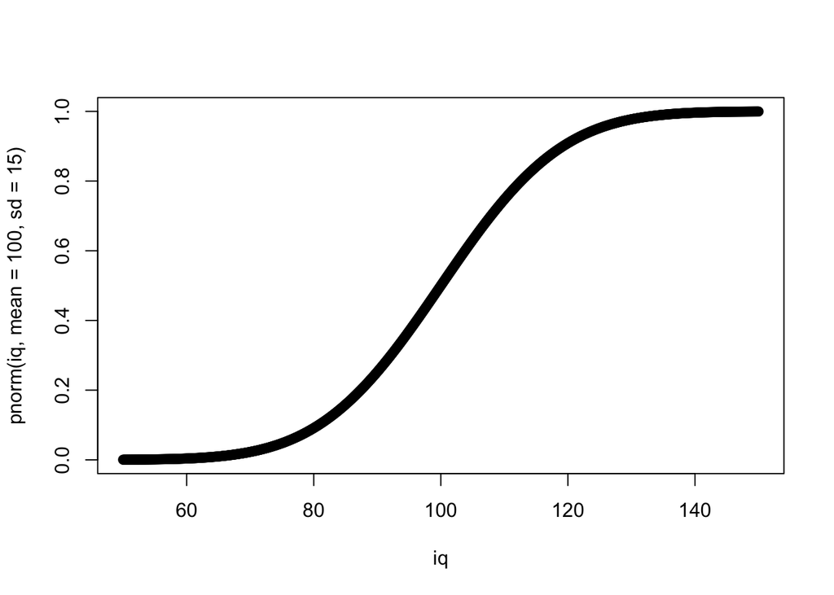

```r
plot(iq, pnorm(iq, mean = 100, sd = 15))
```